# Poject #1 - Classification Class in social networks

Viet Ba Mai, Klaudia Magda

November 25th, 2016

# Introduction

The goal of this project is to predict the number of shares in social networks using the *Online News Popularity* dataset from UCI. This report is to finalise our project by trying different samplings and shares’ divisions to see which works the best for ths problem.

# Previous Phases

## Binary results

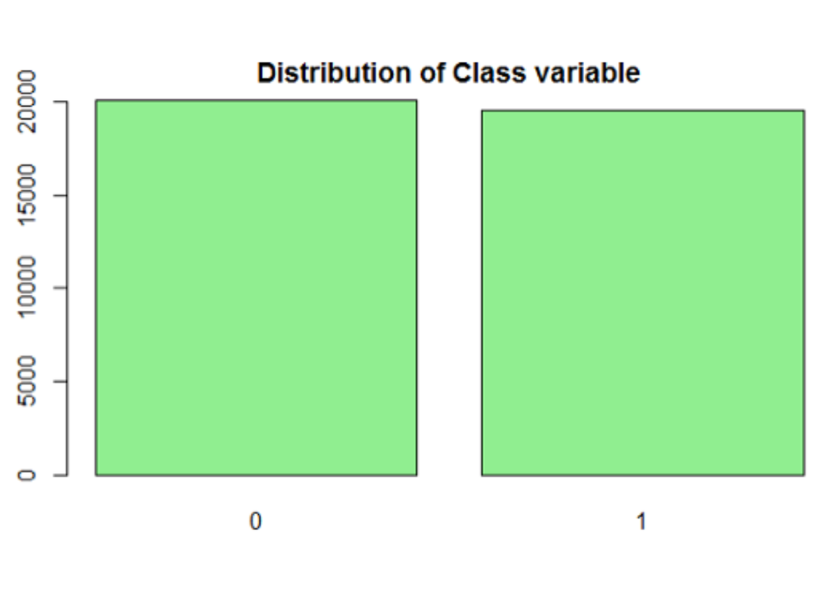

In first phase of our project we used binary classification: if the value of shares was greater than 1400 then we assigned value 1, 0 otherwise. Such division gives us a uniform distribution. Furthermore, we chose 2 classifiers `KNN` and `Random Forest`, where the last one was used twice (for every predictor and for 3 top based on importance).

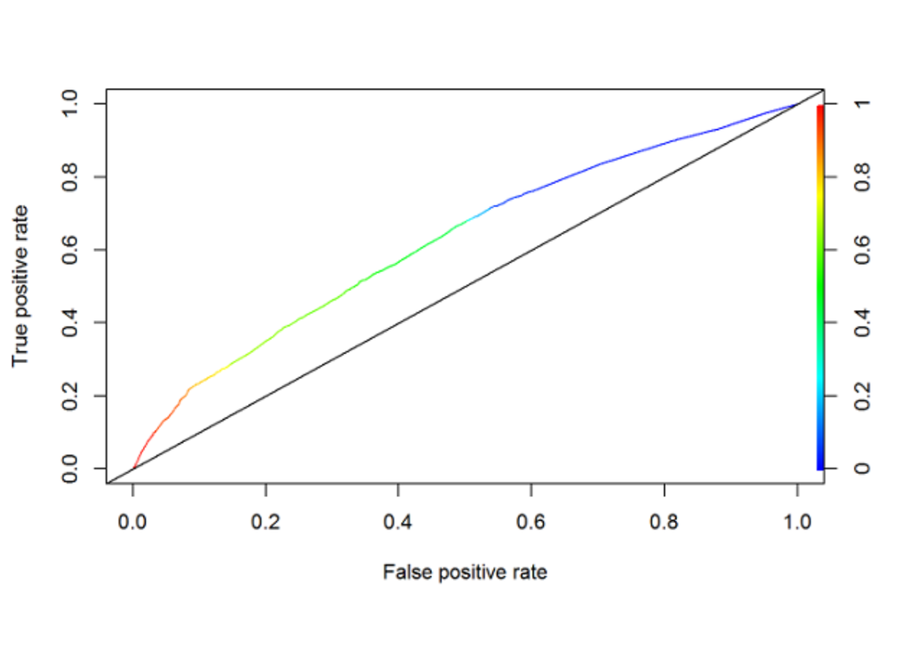

```
##      Accuracy Precision Sensitivity Specificity
## KNN 0.5761949 0.5768072   0.6181158   0.5330287
## RF  0.5865316 0.5850807   0.6360702   0.5355214
## RF3 0.5745574 0.5499750   0.8880371   0.2517657
```

## Multi-class results

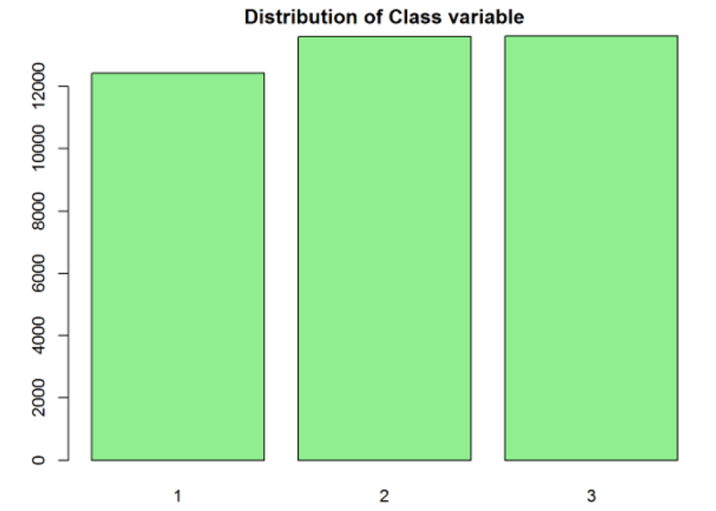

In the second phase the goal was to find the best classifier. We chose to divide the target variable `shares` into 3 classes. The classifiers we used were:

- Random Forest
- Tree
- Nearest Neighbours (KNN)
- Super Vector Machines
- Multinomial Logistic Regression
- Naive Bayes

Additionally we used more techniques of checking performance:

- Confusion Matrix
- Area Under Curve
- Macro-Averaged Metrics (Precision, Recall, F1)

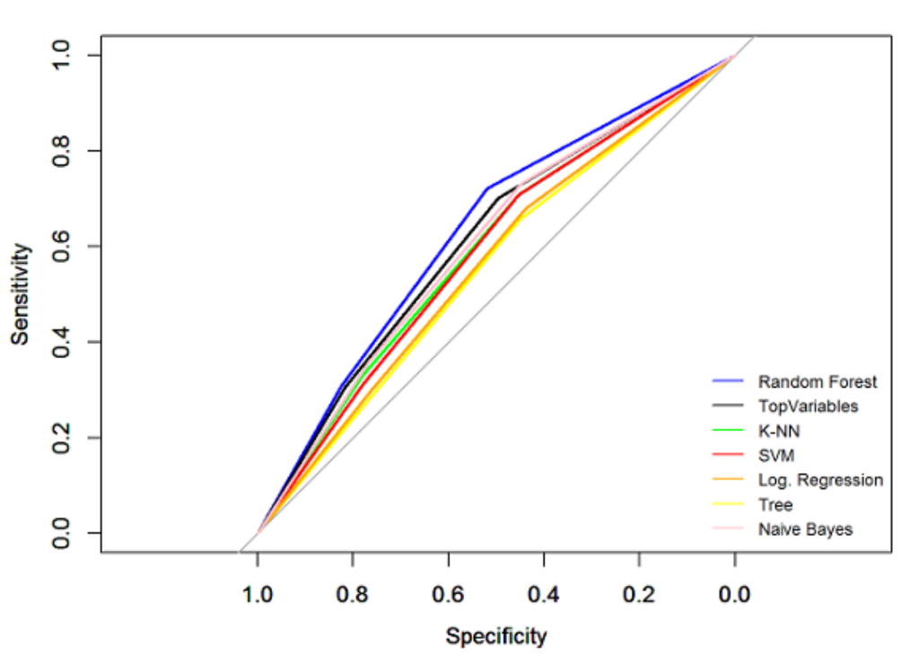

```
##        Accuracy       AUC Precision    Recall        F1
## RF    0.4859277 0.6229207 0.4804962 0.4862377 0.4819532
## TOPRF 0.4754590 0.6100289 0.4616056 0.4650128 0.4621302
## TREE  0.4375192 0.5725785 0.4275352 0.4373422 0.4227565
## KNN   0.4298434 0.6229207 0.4257956 0.4299119 0.4266031
## SVM   0.4307645 0.5746175 0.4263899 0.4313335 0.4276088
## MLR   0.4300481 0.5743767 0.4229383 0.4301481 0.4222412
## BAYES 0.3931020 0.6275691 0.3926283 0.3999613 0.3604131
```

# Summary of previous phases

We can notice that the results of the first phase are satisfying and very close to the one obtained by the authors of the `Predicting and Evaluating the Popularity of Online News` report, so we may assume that the predictors were chosen correctly.

Moreover, we can observe from the summary results table that the best predictions were obtained by Random Forest, with the accuracy of `58%`.

Nevertheless, KNN, being a simpler method, still yields results very close to it. In case of the Random Forest trained with the top 3 variables taken from the importance plot (RF3) the true positive rate (sensitivity) is almost `90%`, but the true negative rate (specificity) is only `25%`. In model fit plots, both the OOB error and in-class OBB error were higher for RF3 than RF, so it was not the best approach to choose only that three predictors.

In the second phase of the project, our goal was to find the best classification model for a multi-class task and compare their performance with various methods hence we implemented 6 distinct classifiers and more approaches to calculate the performance of our methods.

To sum up, in both phases (binary and multi-class) classification experiments showed that Random Forest is the winner, thus we will examine it in more details in this report.

# Shares

The target variable of the set is `shares`. The first thing one can notice is that it contains almost 1500 distinct values, where more of them occur only once. This means that this variable has a very high variance and trying to train the classifiers with it would yield very inaccurate result. More than that the feature selection function we will use in the next sections are unable to handle such a big number of classes.

Our solution to this problem was to create a new target variable with only a few classes representing the ranges of shares.

In the following sections we will divide shares into 3 and 5 classes, each both evenly and not.

For different sampling methods we will use:

- `k-fold` cross validation - divides a set into k-subsets and trains one against all other for each subset. Test is done on a selected subset.
- `bootstrap` - each iteration uses a random sample of the same size.

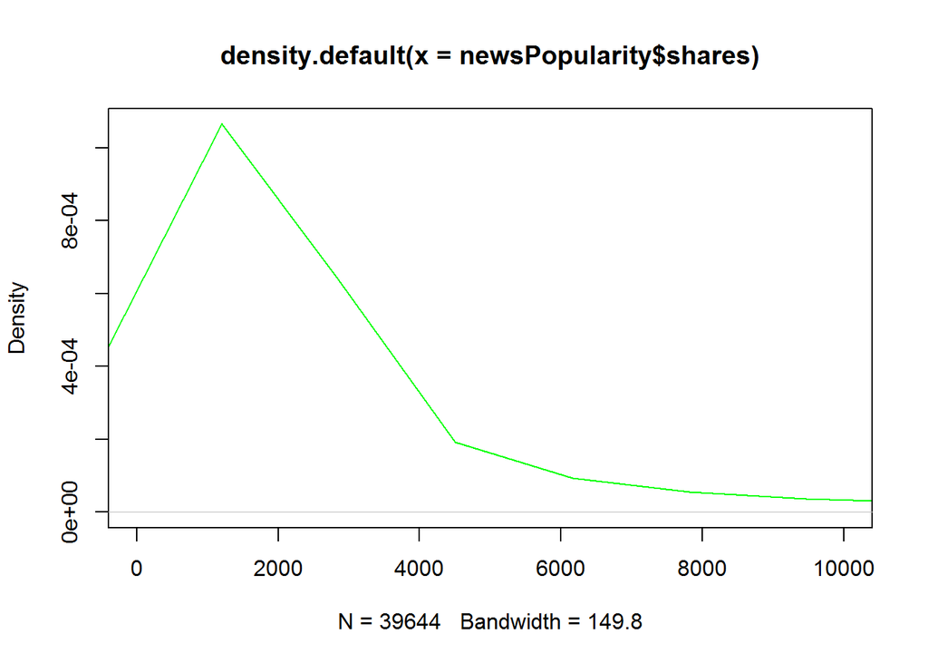

```r
newsPopularity <- read.csv(file.path(file.path(getwd(), "OnlineNewsPopularity"), "OnlineNewsPopularity.csv"), header=TRUE, sep=",", encoding="UTF-8")

newsPopularity <- newsPopularity[complete.cases(newsPopularity),]
newsPopularity <- subset(newsPopularity, select = -c(url, timedelta))
plot(density(newsPopularity$shares), xlim=c(0,10000), col="green")
```

# 3 classes

## Even class distribution

### Data Preparation

```r
#Create a copy
data = newsPopularity

#Divide shares into classes
categories = cut(data$shares, c(0, 1000, 2000, Inf))
data$Class = as.numeric(categories)
data$Class = factor(data$Class)

set.seed(1313)
indx <- createDataPartition(y = data$Class, p = 0.2)

data <- data[indx$Resample1,]
length(levels(data$Class))
```

```
## [1] 3
```

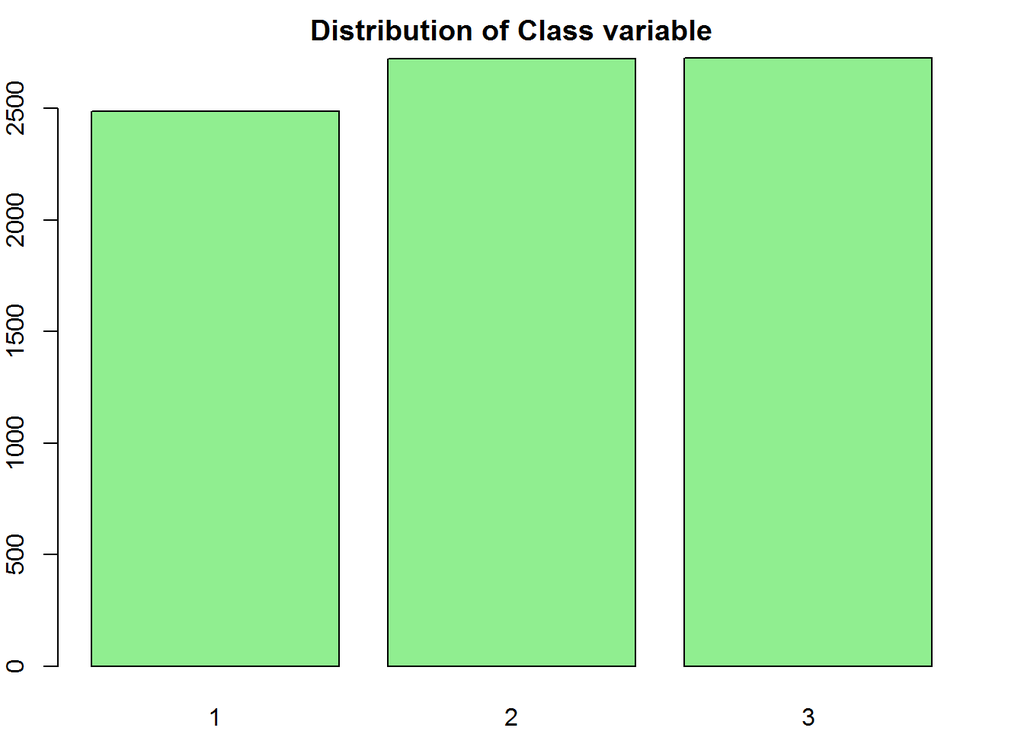

```r
par(mar = rep(2, 4))
barplot(table(data$Class), col="lightgreen", main="Distribution of Class variable")
```

```r
summary(data$Class)
```

```
##    1    2    3
## 2485 2721 2724
```

```r
prop.table(table(data$Class))
```

```
##
##         1         2         3
## 0.3133670 0.3431274 0.3435057
```

```r
data <- subset(data, select = -c(shares))

#Removing near zero variance variables
nzv <- nearZeroVar(data)
names(data)[nzv]
```

```
## [1] "n_non_stop_words" "kw_min_max"
```

```r
data <- data[, -nzv]

#Normalisation
preProcValues <- preProcess(data, method = c("range"))
data <- predict(preProcValues, data)

#Removing highly correlated variables
d.num <- data %>% select(which(sapply(data, is.numeric)))
too_high <- findCorrelation(cor(d.num), cutoff = 0.725, verbose = FALSE)
names(d.num)[too_high]
```

```
##  [1] "rate_positive_words"        "n_non_stop_unique_tokens"
##  [3] "kw_avg_avg"                 "rate_negative_words"
##  [5] "data_channel_is_world"      "avg_negative_polarity"
##  [7] "LDA_04"                     "LDA_00"
##  [9] "kw_max_avg"                 "kw_min_min"
## [11] "self_reference_avg_sharess" "kw_max_min"
```

```r
data = data[,-c(too_high)]

#SBF
set.seed(1313)
indx <- createDataPartition(y = data$Class, p = 0.15)
sample <- data[indx$Resample1,]
filterCtrl <- sbfControl(functions = rfSBF, method = "cv", verbose = FALSE)
rfWithFilter <- sbf(form = Class ~ ., data = sample, sbfControl = filterCtrl, allowParallel = TRUE, variables=TRUE)
rfWithFilter
```

```
##
## Selection By Filter
##
## Outer resampling method: Cross-Validated (10 fold)
##
## Resampling performance:
##
##  Accuracy  Kappa AccuracySD KappaSD
##    0.4584 0.1878    0.06503 0.09741
##
## Using the training set, 21 variables were selected:
##    n_tokens_content, n_unique_tokens, num_hrefs, num_imgs, average_token_length...
##
## During resampling, the top 5 selected variables (out of a possible 25):
##    average_token_length (100%), data_channel_is_entertainment (100%), data_channel_is_socmed (100%), data_channel_is_tech (100%), is_weekend (100%)
##
## On average, 20.3 variables were selected (min = 18, max = 23)
```

```r
selections <- rfWithFilter$variables$selectedVars
selections
```

```
##  [1] "n_tokens_content"              "n_unique_tokens"
##  [3] "num_hrefs"                     "num_imgs"
##  [5] "average_token_length"          "num_keywords"
##  [7] "data_channel_is_entertainment" "data_channel_is_socmed"
##  [9] "data_channel_is_tech"          "kw_max_max"
## [11] "kw_min_avg"                    "self_reference_min_shares"
## [13] "self_reference_max_shares"     "weekday_is_sunday"
## [15] "is_weekend"                    "LDA_01"
## [17] "LDA_02"                        "min_positive_polarity"
```

```r
selections <- append(selections, "Class")

subdata <- data[selections]

#Data splitting
set.seed(1313)
indxTrain <- createDataPartition(y = subdata$Class, p = 0.75)
str(indxTrain)
```

```
## List of 1
##  $ Resample1: int [1:5948] 1 4 6 7 9 10 11 12 13 15 ...
```

```r
dataTrain <- subdata[indxTrain$Resample1,]
dataTest <- subdata[-indxTrain$Resample1,]
```

### Random Forest

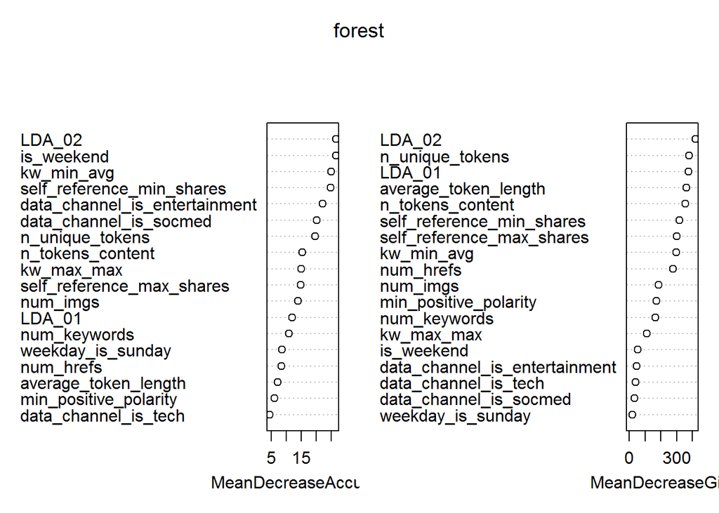

```r
forest <- randomForest(Class ~ ., data = dataTrain, importance = TRUE, na.action = na.omit)
varImpPlot(forest)
```

```r
importance(forest)
```

```
##                                       1           2         3
## n_tokens_content              16.138635  0.29065639  6.646156
## n_unique_tokens               18.673722  4.77802242  6.131042
## num_hrefs                     12.247717 -6.19031598  8.485420
## num_imgs                      17.893166  4.10057554  1.558179
## average_token_length          11.230593 -1.97985199  2.819320
## num_keywords                  11.918313  0.64415748  5.064739
## data_channel_is_entertainment 22.691751  0.48742034  9.918895
## data_channel_is_socmed        22.232588 -0.01597047 16.380896
## data_channel_is_tech           6.129327 -0.17364266  1.256721
## kw_max_max                     8.569385  5.53562993 11.555685
## kw_min_avg                    33.354869 -0.25447305 10.574008
## self_reference_min_shares     19.263743  1.00931380 19.860819
## self_reference_max_shares      7.668329 -3.29405078 17.380916
## weekday_is_sunday             11.616494  4.72208801 -1.650736
## is_weekend                    37.207130  6.86078791  5.031975
## LDA_01                        13.645041  0.09892421  6.341224
## LDA_02                        32.827295 -4.21134970 15.991017
## min_positive_polarity          5.282777 -1.06083204  5.166746
##                               MeanDecreaseAccuracy MeanDecreaseGini
## n_tokens_content                         15.324918        354.39476
## n_unique_tokens                          19.570331        376.74223
## num_hrefs                                 8.297782        277.38028
## num_imgs                                 13.890387        184.11705
## average_token_length                      7.073920        361.89167
## num_keywords                             10.806640        164.08041
## data_channel_is_entertainment            22.080549         48.76139
## data_channel_is_socmed                   20.038283         32.08300
## data_channel_is_tech                      4.475012         39.57837
## kw_max_max                               15.010702        112.82924
## kw_min_avg                               24.839787        298.04408
## self_reference_min_shares                24.750892        317.82156
## self_reference_max_shares                14.796508        300.99170
## weekday_is_sunday                         8.477439         20.02050
## is_weekend                               26.477854         52.62600
## LDA_01                                   11.974098        376.32678
## LDA_02                                   26.547668        419.45013
## min_positive_polarity                     6.151089        171.41264
```

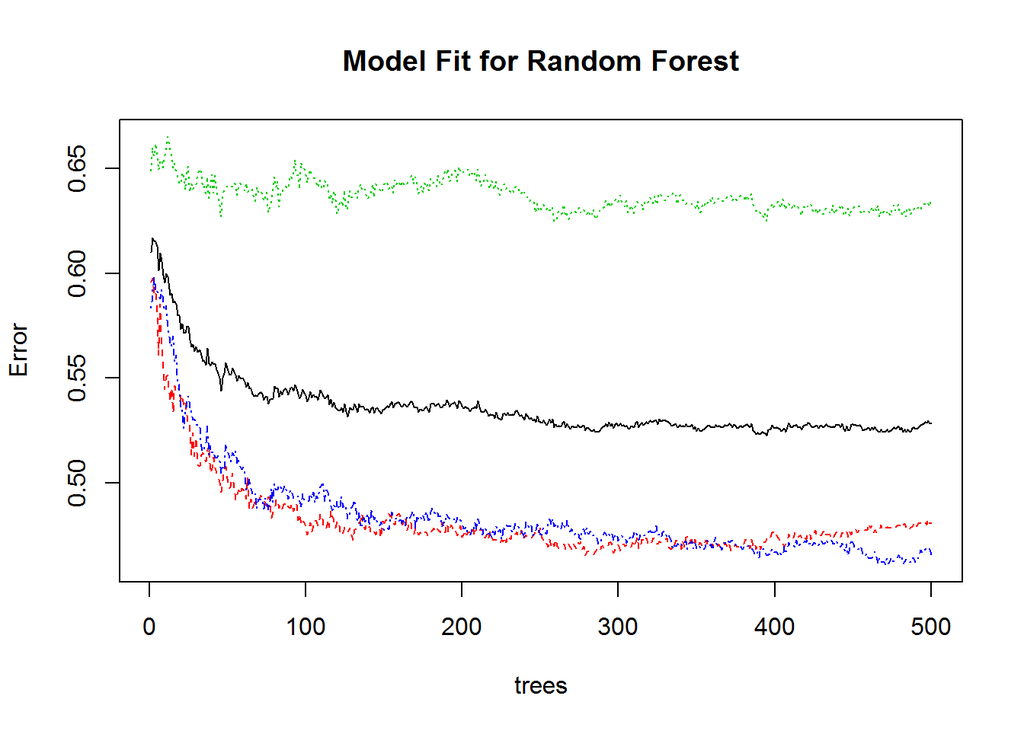

```r
predForest = predict(forest, dataTest, type="class")
plot(forest, main="Model Fit for Random Forest")
```

```r
confusionMatrix(predForest, dataTest$Class)
```

```
## $positive
## NULL
##
## $table
##           Reference
## Prediction   1   2   3
##          1 344 163 105
##          2 165 254 230
##          3 112 263 346
##
## $overall
##       Accuracy          Kappa  AccuracyLower  AccuracyUpper   AccuracyNull
##   4.762866e-01   2.135495e-01   4.540956e-01   4.985478e-01   3.435923e-01
## AccuracyPValue  McnemarPValue
##   3.532676e-34   4.849590e-01
##
## $byClass
##          Sensitivity Specificity Pos Pred Value Neg Pred Value Precision
## Class: 1   0.5539452   0.8030860      0.5620915      0.7978102 0.5620915
## Class: 2   0.3735294   0.6966206      0.3913713      0.6804201 0.3913713
## Class: 3   0.5080764   0.7117602      0.4798890      0.7343378 0.4798890
##             Recall        F1 Prevalence Detection Rate
## Class: 1 0.5539452 0.5579886  0.3133199      0.1735621
## Class: 2 0.3735294 0.3822423  0.3430878      0.1281534
## Class: 3 0.5080764 0.4935806  0.3435923      0.1745711
##          Detection Prevalence Balanced Accuracy
## Class: 1             0.308779         0.6785156
## Class: 2             0.327447         0.5350750
## Class: 3             0.363774         0.6099183
##
## $mode
## [1] "sens_spec"
##
## $dots
## list()
##
## attr(,"class")
## [1] "confusionMatrix"
```

```r
tab <- table(true = dataTest$Class, predicted = predForest)
rf3eAcc <- sum(diag(tab)) / sum(tab)
rf3eAcc
```

```
## [1] 0.4762866
```

### K-fold cross validation

```r
kfold <- train(Class ~ ., data = subdata, trControl=trainControl(method="cv", number=3), method="rf")
kfpred <- predict(kfold, subdata)

confusionMatrix(kfpred, subdata$Class)
```

```
## $positive
## NULL
##
## $table
##           Reference
## Prediction    1    2    3
##          1 2450   53   59
##          2    3 2631    1
##          3   32   37 2664
##
## $overall
##       Accuracy          Kappa  AccuracyLower  AccuracyUpper   AccuracyNull
##   9.766709e-01   9.649901e-01   9.731051e-01   9.798801e-01   3.435057e-01
## AccuracyPValue  McnemarPValue
##   0.000000e+00   1.087723e-18
##
## $byClass
##          Sensitivity Specificity Pos Pred Value Neg Pred Value Precision
## Class: 1   0.9859155   0.9794307      0.9562842      0.9934799 0.9562842
## Class: 2   0.9669239   0.9992321      0.9984820      0.9830028 0.9984820
## Class: 3   0.9779736   0.9867461      0.9747530      0.9884549 0.9747530
##             Recall        F1 Prevalence Detection Rate
## Class: 1 0.9859155 0.9708738  0.3133670      0.3089533
## Class: 2 0.9669239 0.9824496  0.3431274      0.3317781
## Class: 3 0.9779736 0.9763606  0.3435057      0.3359395
##          Detection Prevalence Balanced Accuracy
## Class: 1            0.3230769         0.9826731
## Class: 2            0.3322825         0.9830780
## Class: 3            0.3446406         0.9823598
##
## $mode
## [1] "sens_spec"
##
## $dots
## list()
##
## attr(,"class")
## [1] "confusionMatrix"
```

```r
tab <- table(true = subdata$Class, predicted = kfpred)
kf3eAcc <- sum(diag(tab)) / sum(tab)
kf3eAcc
```

```
## [1] 0.9766709
```

### Bootstrap

```r
bstrap <- train(Class ~ ., data = subdata, trControl=trainControl(method="boot", number=3), method="rf")
bspred <- predict(bstrap, subdata)

confusionMatrix(bspred, subdata$Class)
```

```
## $positive
## NULL
##
## $table
##           Reference
## Prediction    1    2    3
##          1 2446   68   67
##          2    3 2613    1
##          3   36   40 2656
##
## $overall
##       Accuracy          Kappa  AccuracyLower  AccuracyUpper   AccuracyNull
##   9.728878e-01   9.593171e-01   9.690717e-01   9.763508e-01   3.435057e-01
## AccuracyPValue  McnemarPValue
##   0.000000e+00   8.223835e-23
##
## $byClass
##          Sensitivity Specificity Pos Pred Value Neg Pred Value Precision
## Class: 1   0.9843058   0.9752066      0.9476947      0.9927089 0.9476947
## Class: 2   0.9603087   0.9992321      0.9984715      0.9796725 0.9984715
## Class: 3   0.9750367   0.9854015      0.9721816      0.9869180 0.9721816
##             Recall        F1 Prevalence Detection Rate
## Class: 1 0.9843058 0.9656534  0.3133670      0.3084489
## Class: 2 0.9603087 0.9790184  0.3431274      0.3295082
## Class: 3 0.9750367 0.9736070  0.3435057      0.3349306
##          Detection Prevalence Balanced Accuracy
## Class: 1            0.3254729         0.9797562
## Class: 2            0.3300126         0.9797704
## Class: 3            0.3445145         0.9802191
##
## $mode
## [1] "sens_spec"
##
## $dots
## list()
##
## attr(,"class")
## [1] "confusionMatrix"
```

```r
tab <- table(true = subdata$Class, predicted = bspred)
bs3eAcc <- sum(diag(tab)) / sum(tab)
bs3eAcc
```

```
## [1] 0.9728878
```

## Uneven class distribution

### Data Preparation

```r
#Create a copy
data = newsPopularity

#Divide shares into classes
categories = cut(data$shares, c(0, 1500, 4000, Inf))
data$Class = as.numeric(categories)
data$Class = factor(data$Class)

set.seed(1313)
indx <- createDataPartition(y = data$Class, p = 0.2)

data <- data[indx$Resample1,]
length(levels(data$Class))
```

```
## [1] 3
```

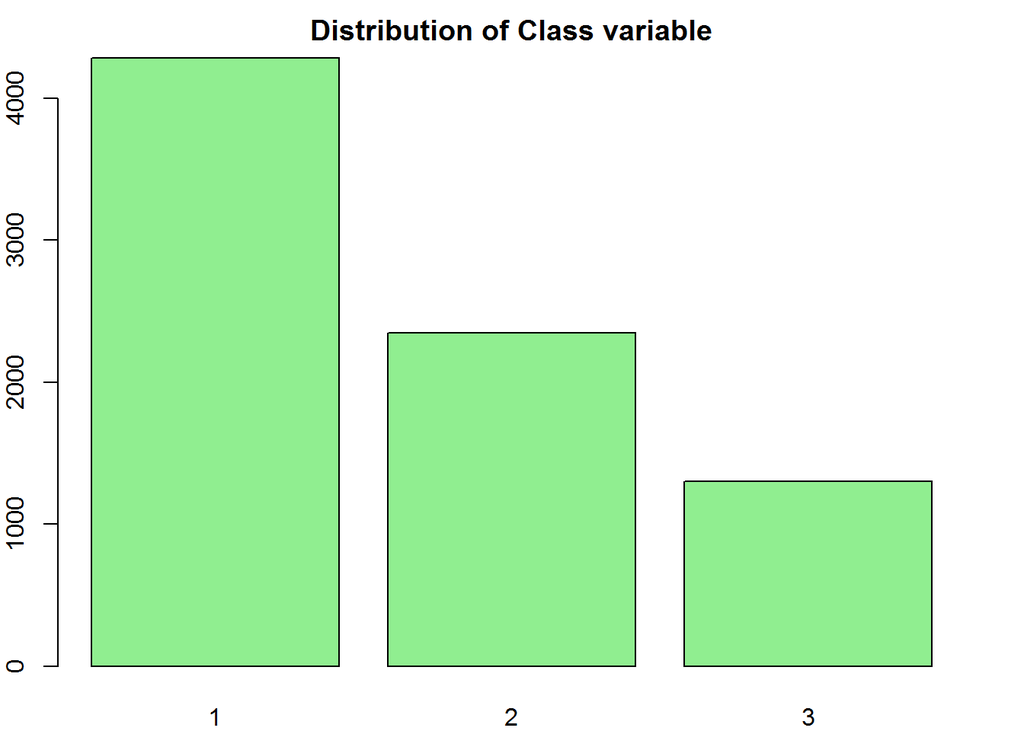

```r
par(mar = rep(2, 4))
barplot(table(data$Class), col="lightgreen", main="Distribution of Class variable")
```

```r
summary(data$Class)
```

```
##    1    2    3
## 4281 2349 1300
```

```r
prop.table(table(data$Class))
```

```
##
##         1         2         3
## 0.5398487 0.2962169 0.1639344
```

```r
data <- subset(data, select = -c(shares))

#Removing near zero variance variables
nzv <- nearZeroVar(data)
names(data)[nzv]
```

```
## [1] "n_non_stop_words" "kw_min_max"
```

```r
data <- data[, -nzv]

#Normalisation
preProcValues <- preProcess(data, method = c("range"))
data <- predict(preProcValues, data)

#Removing highly correlated variables
d.num <- data %>% select(which(sapply(data, is.numeric)))
too_high <- findCorrelation(cor(d.num), cutoff = 0.725, verbose = FALSE)
names(d.num)[too_high]
```

```
##  [1] "rate_positive_words"       "n_non_stop_unique_tokens"
##  [3] "kw_avg_avg"                "avg_negative_polarity"
##  [5] "rate_negative_words"       "data_channel_is_world"
##  [7] "LDA_04"                    "LDA_00"
##  [9] "kw_min_min"                "self_reference_max_shares"
## [11] "kw_max_min"                "self_reference_min_shares"
```

```r
data = data[,-c(too_high)]

#SBF
set.seed(1313)
indx <- createDataPartition(y = data$Class, p = 0.15)
sample <- data[indx$Resample1,]
filterCtrl <- sbfControl(functions = rfSBF, method = "cv", verbose = FALSE)
rfWithFilter <- sbf(form = Class ~ ., data = sample, sbfControl = filterCtrl, allowParallel = TRUE, variables=TRUE)
rfWithFilter
```

```
##
## Selection By Filter
##
## Outer resampling method: Cross-Validated (10 fold)
##
## Resampling performance:
##
##  Accuracy  Kappa AccuracySD KappaSD
##    0.5516 0.1326    0.02918 0.04994
##
## Using the training set, 21 variables were selected:
##    n_tokens_content, num_hrefs, data_channel_is_entertainment, data_channel_is_socmed, data_channel_is_tech...
##
## During resampling, the top 5 selected variables (out of a possible 26):
##    avg_positive_polarity (100%), data_channel_is_socmed (100%), global_subjectivity (100%), is_weekend (100%), kw_min_avg (100%)
##
## On average, 20.9 variables were selected (min = 19, max = 22)
```

```r
selections <- rfWithFilter$variables$selectedVars
selections
```

```
##  [1] "n_tokens_content"              "num_hrefs"
##  [3] "data_channel_is_entertainment" "data_channel_is_socmed"
##  [5] "data_channel_is_tech"          "kw_avg_min"
##  [7] "kw_min_avg"                    "kw_max_avg"
##  [9] "self_reference_avg_sharess"    "weekday_is_tuesday"
## [11] "weekday_is_saturday"           "weekday_is_sunday"
## [13] "is_weekend"                    "LDA_01"
## [15] "LDA_02"                        "LDA_03"
## [17] "global_subjectivity"           "global_sentiment_polarity"
## [19] "global_rate_positive_words"    "avg_positive_polarity"
## [21] "max_positive_polarity"         "title_sentiment_polarity"
```

```r
selections <- append(selections, "Class")

subdata <- data[selections]

#Data splitting
set.seed(1313)
indxTrain <- createDataPartition(y = subdata$Class, p = 0.75)
str(indxTrain)
```

```
## List of 1
##  $ Resample1: int [1:5948] 2 4 6 7 9 10 11 12 14 15 ...
```

```r
dataTrain <- subdata[indxTrain$Resample1,]
dataTest <- subdata[-indxTrain$Resample1,]
```

### Random Forest

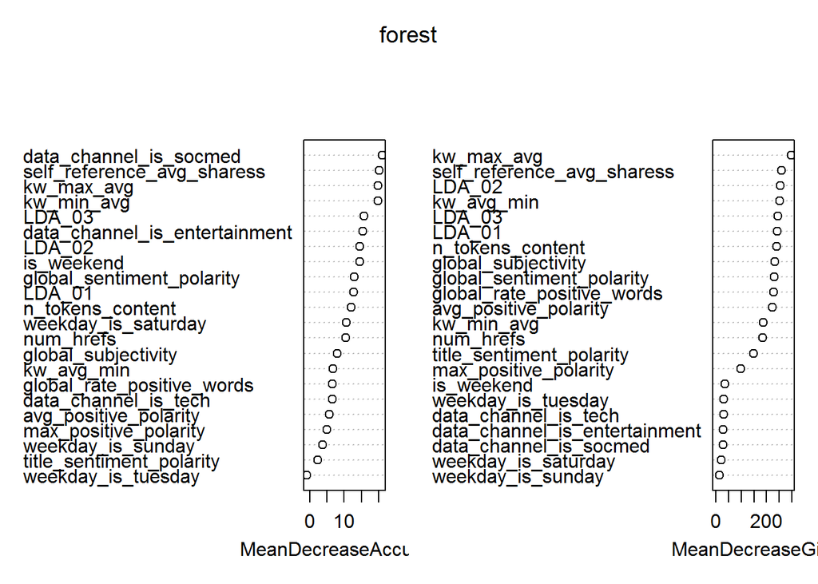

```r
forest <- randomForest(Class ~ ., data = dataTrain, importance = TRUE, na.action = na.omit)
varImpPlot(forest)
```

```r
importance(forest)
```

```
##                                        1          2          3
## n_tokens_content              15.7267672 -1.5925637  0.8295374
## num_hrefs                     13.7679504 -3.8525298  2.9974056
## data_channel_is_entertainment 15.5502937  2.5797196 -2.2585594
## data_channel_is_socmed        17.4632390 11.0934251  5.5655148
## data_channel_is_tech           7.5373094 -0.4392819  0.8770500
## kw_avg_min                     6.5941084  2.1343515  0.7541907
## kw_min_avg                    24.7556640 -4.8683804  3.9822098
## kw_max_avg                    17.0025531 -5.3849520 25.2325237
## self_reference_avg_sharess    18.0436753 -1.0837407 20.5832506
## weekday_is_tuesday             0.3559113 -1.1781031 -1.7654747
## weekday_is_saturday           11.9009489  2.5949642 -1.3839994
## weekday_is_sunday              6.7332065 -1.3510355 -2.1185929
## is_weekend                    16.8530734  3.0670614 -1.1366472
## LDA_01                        16.4485568  0.5200764 -4.2398036
## LDA_02                        17.1682107 -6.7436510  7.6930718
## LDA_03                        18.8573588 -4.6008913  5.2945205
## global_subjectivity           12.9330061 -3.0481284 -2.6181219
## global_sentiment_polarity     15.7806937 -0.8670873 -2.4363397
## global_rate_positive_words     9.0732443 -2.6855528  1.8659745
## avg_positive_polarity         11.1626216 -5.0537382 -1.5412285
## max_positive_polarity          7.2801104 -1.1199052 -0.8088157
## title_sentiment_polarity       2.1706100  1.0030796  0.2476355
##                               MeanDecreaseAccuracy MeanDecreaseGini
## n_tokens_content                        11.9835753        238.90103
## num_hrefs                               10.5162147        185.65237
## data_channel_is_entertainment           15.4093624         29.43103
## data_channel_is_socmed                  21.1514877         28.90739
## data_channel_is_tech                     6.6012158         30.19222
## kw_avg_min                               6.6603503        250.59558
## kw_min_avg                              19.8218839        187.54790
## kw_max_avg                              19.9371951        297.62520
## self_reference_avg_sharess              20.2946170        259.36275
## weekday_is_tuesday                      -0.8963508         30.87639
## weekday_is_saturday                     10.6966278         20.99367
## weekday_is_sunday                        3.6971334         14.70164
## is_weekend                              14.5023351         35.18714
## LDA_01                                  12.7104267        241.27883
## LDA_02                                  14.5355249        254.40219
## LDA_03                                  15.8706583        244.21786
## global_subjectivity                      7.9007763        233.19728
## global_sentiment_polarity               12.8657782        230.17921
## global_rate_positive_words               6.6405169        228.08468
## avg_positive_polarity                    5.6342031        221.76696
## max_positive_polarity                    5.0259074         98.66059
## title_sentiment_polarity                 2.2945725        149.11683
```

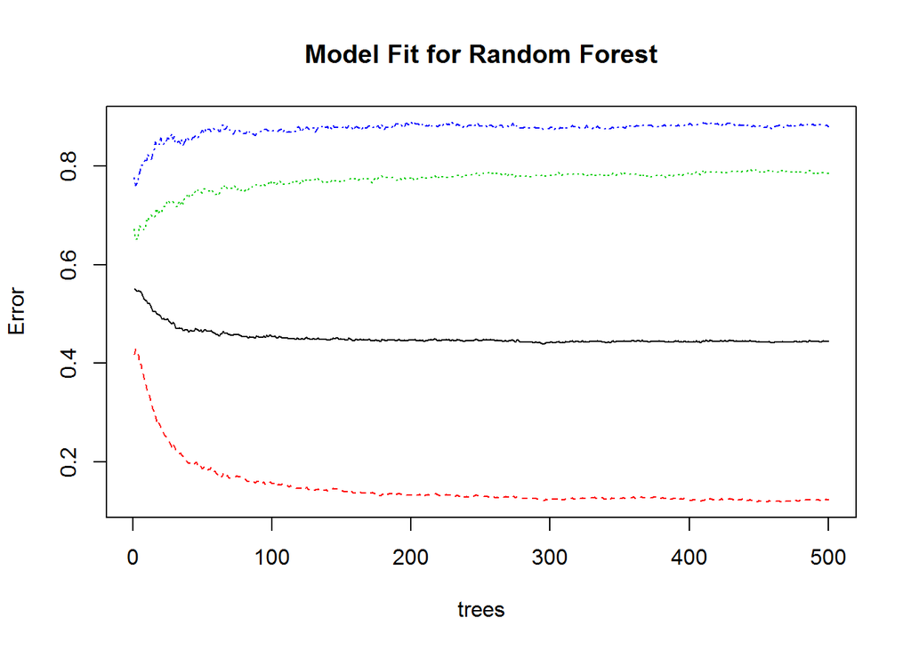

```r
predForest = predict(forest, dataTest, type="class")
plot(forest, main="Model Fit for Random Forest")
```

```r
confusionMatrix(predForest, dataTest$Class)
```

```
## $positive
## NULL
##
## $table
##           Reference
## Prediction   1   2   3
##          1 974 397 211
##          2  69 146  73
##          3  27  44  41
##
## $overall
##       Accuracy          Kappa  AccuracyLower  AccuracyUpper   AccuracyNull
##   5.857719e-01   1.984633e-01   5.637199e-01   6.075698e-01   5.398587e-01
## AccuracyPValue  McnemarPValue
##   2.149871e-05   4.078589e-82
##
## $byClass
##          Sensitivity Specificity Pos Pred Value Neg Pred Value Precision
## Class: 1   0.9102804   0.3333333      0.6156764      0.7600000 0.6156764
## Class: 2   0.2487223   0.8982079      0.5069444      0.7396694 0.5069444
## Class: 3   0.1261538   0.9571515      0.3660714      0.8481283 0.3660714
##             Recall        F1 Prevalence Detection Rate
## Class: 1 0.9102804 0.7345400  0.5398587     0.49142281
## Class: 2 0.2487223 0.3337143  0.2961655     0.07366297
## Class: 3 0.1261538 0.1876430  0.1639758     0.02068618
##          Detection Prevalence Balanced Accuracy
## Class: 1           0.79818365         0.6218069
## Class: 2           0.14530777         0.5734651
## Class: 3           0.05650858         0.5416527
##
## $mode
## [1] "sens_spec"
##
## $dots
## list()
##
## attr(,"class")
## [1] "confusionMatrix"
```

```r
tab <- table(true = dataTest$Class, predicted = predForest)
rf3unAcc <- sum(diag(tab)) / sum(tab)
rf3unAcc
```

```
## [1] 0.5857719
```

### K-fold cross validation

```r
kfold <- train(Class ~ ., data = subdata, trControl=trainControl(method="cv", number=3), method="rf")
kfpred <- predict(kfold, subdata)

confusionMatrix(kfpred, subdata$Class)
```

```
## $positive
## NULL
##
## $table
##           Reference
## Prediction    1    2    3
##          1 4281   73   96
##          2    0 2276    0
##          3    0    0 1204
##
## $overall
##       Accuracy          Kappa  AccuracyLower  AccuracyUpper   AccuracyNull
##      0.9786885      0.9637036      0.9752653      0.9817533      0.5398487
## AccuracyPValue  McnemarPValue
##      0.0000000            NaN
##
## $byClass
##          Sensitivity Specificity Pos Pred Value Neg Pred Value Precision
## Class: 1   1.0000000   0.9536859      0.9620225      1.0000000 0.9620225
## Class: 2   0.9689229   1.0000000      1.0000000      0.9870888 1.0000000
## Class: 3   0.9261538   1.0000000      1.0000000      0.9857270 1.0000000
##             Recall        F1 Prevalence Detection Rate
## Class: 1 1.0000000 0.9806437  0.5398487      0.5398487
## Class: 2 0.9689229 0.9842162  0.2962169      0.2870113
## Class: 3 0.9261538 0.9616613  0.1639344      0.1518285
##          Detection Prevalence Balanced Accuracy
## Class: 1            0.5611602         0.9768430
## Class: 2            0.2870113         0.9844615
## Class: 3            0.1518285         0.9630769
##
## $mode
## [1] "sens_spec"
##
## $dots
## list()
##
## attr(,"class")
## [1] "confusionMatrix"
```

```r
tab <- table(true = subdata$Class, predicted = kfpred)
kf3unAcc <- sum(diag(tab)) / sum(tab)
kf3unAcc
```

```
## [1] 0.9786885
```

### Bootstrap

```r
bstrap <- train(Class ~ ., data = subdata, trControl=trainControl(method="boot", number=3), method="rf")
bspred <- predict(bstrap, subdata)

confusionMatrix(bspred, subdata$Class)
```

```
## $positive
## NULL
##
## $table
##           Reference
## Prediction    1    2    3
##          1 4281   86   94
##          2    0 2263    0
##          3    0    0 1206
##
## $overall
##       Accuracy          Kappa  AccuracyLower  AccuracyUpper   AccuracyNull
##      0.9773014      0.9613210      0.9737794      0.9804662      0.5398487
## AccuracyPValue  McnemarPValue
##      0.0000000            NaN
##
## $byClass
##          Sensitivity Specificity Pos Pred Value Neg Pred Value Precision
## Class: 1   1.0000000   0.9506714      0.9596503      1.0000000 0.9596503
## Class: 2   0.9633887   1.0000000      1.0000000      0.9848244 1.0000000
## Class: 3   0.9276923   1.0000000      1.0000000      0.9860202 1.0000000
##             Recall        F1 Prevalence Detection Rate
## Class: 1 1.0000000 0.9794097  0.5398487      0.5398487
## Class: 2 0.9633887 0.9813530  0.2962169      0.2853720
## Class: 3 0.9276923 0.9624900  0.1639344      0.1520807
##          Detection Prevalence Balanced Accuracy
## Class: 1            0.5625473         0.9753357
## Class: 2            0.2853720         0.9816943
## Class: 3            0.1520807         0.9638462
##
## $mode
## [1] "sens_spec"
##
## $dots
## list()
##
## attr(,"class")
## [1] "confusionMatrix"
```

```r
tab <- table(true = subdata$Class, predicted = bspred)
bs3unAcc <- sum(diag(tab)) / sum(tab)
bs3unAcc
```

```
## [1] 0.9773014
```

# 5 classes

## Even class distribution

### Data Preparation

```r
#Create a copy
data = newsPopularity

#Divide shares into classes
categories = cut(data$shares, c(0, 900, 1200, 1800, 3500, Inf))
data$Class = as.numeric(categories)
data$Class = factor(data$Class)

set.seed(1313)
indx <- createDataPartition(y = data$Class, p = 0.2)

data <- data[indx$Resample1,]
length(levels(data$Class))
```

```
## [1] 5
```

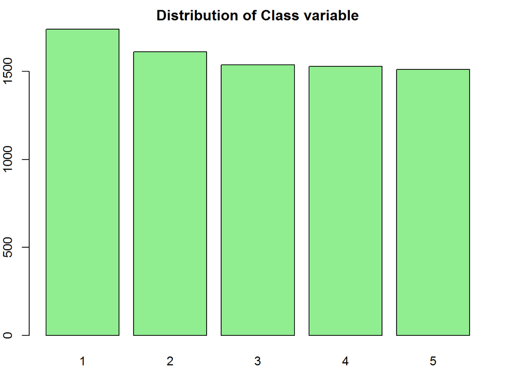

```r
par(mar = rep(2, 4))
barplot(table(data$Class), col="lightgreen", main="Distribution of Class variable")
```

```r
summary(data$Class)
```

```
##    1    2    3    4    5
## 1740 1611 1539 1529 1512
```

```r
prop.table(table(data$Class))
```

```
##
##         1         2         3         4         5
## 0.2193923 0.2031270 0.1940487 0.1927878 0.1906443
```

```r
data <- subset(data, select = -c(shares))

#Removing near zero variance variables
nzv <- nearZeroVar(data)
names(data)[nzv]
```

```
## [1] "n_non_stop_words" "kw_min_max"
```

```r
data <- data[, -nzv]

#Normalisation
preProcValues <- preProcess(data, method = c("range"))
data <- predict(preProcValues, data)

#Removing highly correlated variables
d.num <- data %>% select(which(sapply(data, is.numeric)))
too_high <- findCorrelation(cor(d.num), cutoff = 0.725, verbose = FALSE)
names(d.num)[too_high]
```

```
##  [1] "rate_positive_words"        "kw_avg_avg"
##  [3] "data_channel_is_world"      "avg_negative_polarity"
##  [5] "rate_negative_words"        "LDA_04"
##  [7] "LDA_00"                     "self_reference_avg_sharess"
##  [9] "kw_max_max"                 "kw_max_min"
## [11] "n_non_stop_unique_tokens"
```

```r
data = data[,-c(too_high)]

#SBF
set.seed(1313)
indx <- createDataPartition(y = data$Class, p = 0.15)
sample <- data[indx$Resample1,]
filterCtrl <- sbfControl(functions = rfSBF, method = "cv", verbose = FALSE)
rfWithFilter <- sbf(form = Class ~ ., data = sample, sbfControl = filterCtrl, allowParallel = TRUE, variables=TRUE)
rfWithFilter
```

```
##
## Selection By Filter
##
## Outer resampling method: Cross-Validated (10 fold)
##
## Resampling performance:
##
##  Accuracy Kappa AccuracySD KappaSD
##     0.305 0.129    0.03843 0.04794
##
## Using the training set, 21 variables were selected:
##    n_unique_tokens, num_hrefs, num_imgs, num_keywords, data_channel_is_socmed...
##
## During resampling, the top 5 selected variables (out of a possible 28):
##    data_channel_is_tech (100%), global_subjectivity (100%), is_weekend (100%), kw_avg_max (100%), kw_max_avg (100%)
##
## On average, 21.7 variables were selected (min = 19, max = 25)
```

```r
selections <- rfWithFilter$variables$selectedVars
selections
```

```
##  [1] "n_unique_tokens"               "num_hrefs"
##  [3] "num_imgs"                      "num_keywords"
##  [5] "data_channel_is_entertainment" "data_channel_is_socmed"
##  [7] "data_channel_is_tech"          "kw_min_min"
##  [9] "kw_avg_max"                    "kw_min_avg"
## [11] "kw_max_avg"                    "self_reference_max_shares"
## [13] "weekday_is_saturday"           "weekday_is_sunday"
## [15] "is_weekend"                    "LDA_01"
## [17] "LDA_02"                        "LDA_03"
## [19] "global_subjectivity"           "global_sentiment_polarity"
## [21] "global_rate_positive_words"    "min_positive_polarity"
## [23] "title_sentiment_polarity"
```

```r
selections <- append(selections, "Class")

subdata <- data[selections]

#Data splitting
set.seed(1313)
indxTrain <- createDataPartition(y = subdata$Class, p = 0.75)
str(indxTrain)
```

```
## List of 1
##  $ Resample1: int [1:5950] 1 5 6 7 9 10 11 13 15 16 ...
```

```r
dataTrain <- subdata[indxTrain$Resample1,]
dataTest <- subdata[-indxTrain$Resample1,]
```

### Random Forest

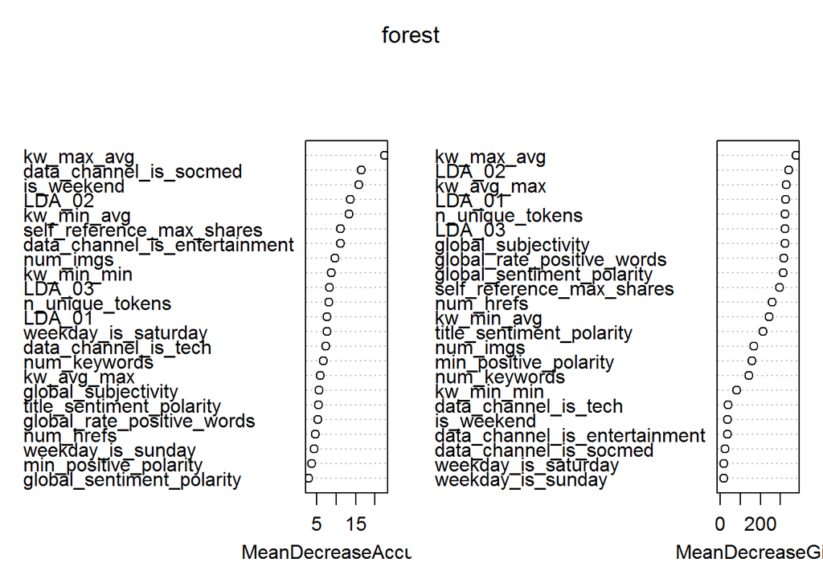

```r
forest <- randomForest(Class ~ ., data = dataTrain, importance = TRUE, na.action = na.omit)
varImpPlot(forest)
```

```r
importance(forest)
```

```
##                                       1           2            3
## n_unique_tokens                7.366194  0.64600876 -1.454782881
## num_hrefs                      4.424419 -0.85088657  0.006364609
## num_imgs                       8.862605  3.08760659  4.830001782
## num_keywords                   7.071215  0.97495496  0.266584914
## data_channel_is_entertainment 13.784059  1.39606264  1.433442046
## data_channel_is_socmed        14.964376  2.55837036  0.978852859
## data_channel_is_tech           8.933001  1.35221103 -2.069669724
## kw_min_min                     8.981173 -0.51712091  1.097560390
## kw_avg_max                     8.995437  2.40682748 -0.851587635
## kw_min_avg                    21.010023  9.62146762 -2.527614291
## kw_max_avg                    16.096733  5.06723829 -1.808605020
## self_reference_max_shares     13.692970  0.62932737 -3.661362590
## weekday_is_saturday           10.953269  1.14580328  5.382257711
## weekday_is_sunday              7.664987  4.55760691 -1.103264015
## is_weekend                    25.546576  3.73804387  4.178846864
## LDA_01                         9.786901  1.26450978 -2.055856657
## LDA_02                        16.043136  2.29507724 -3.549724717
## LDA_03                         7.153252  1.48395825 -0.761204223
## global_subjectivity            4.888501  1.13510991 -0.348722428
## global_sentiment_polarity      4.590413  0.05324836 -0.415599190
## global_rate_positive_words     8.968404 -0.97742397 -0.906488848
## min_positive_polarity          2.820867 -0.84215849 -1.447021816
## title_sentiment_polarity       7.201565  2.16505509 -2.210575781
##                                        4          5 MeanDecreaseAccuracy
## n_unique_tokens               -0.2784351  9.5509309             8.029536
## num_hrefs                     -0.7776590  6.5553661             4.572539
## num_imgs                       1.8140265  1.4893286             9.661720
## num_keywords                   2.0482198  3.0500346             6.675520
## data_channel_is_entertainment  3.2011638  1.3192109            11.044772
## data_channel_is_socmed        11.5745740 10.0498909            16.447169
## data_channel_is_tech           3.6736579  2.8401948             7.258643
## kw_min_min                     6.5399670  1.0566481             8.775822
## kw_avg_max                    -0.3804427  1.0276699             5.959577
## kw_min_avg                    -7.4154427  6.0787681            13.369219
## kw_max_avg                     5.1919266 22.9634162            22.473996
## self_reference_max_shares      1.5137373 11.1950518            11.126601
## weekday_is_saturday            2.4887031 -3.6188735             7.543460
## weekday_is_sunday             -0.3656061 -1.2863286             4.308862
## is_weekend                     4.4733906  0.8764393            15.865817
```

[output cut: 17 more lines]

```
## kw_avg_max                           330.20233
## kw_min_avg                           243.42018
## kw_max_avg                           378.70433
## self_reference_max_shares            295.21587
## weekday_is_saturday                   19.01105
## weekday_is_sunday                     17.91517
## is_weekend                            37.93500
## LDA_01                               326.71273
## LDA_02                               342.01901
## LDA_03                               324.45790
## global_subjectivity                  323.45063
## global_sentiment_polarity            313.94598
## global_rate_positive_words           316.50675
## min_positive_polarity                159.43643
## title_sentiment_polarity             212.06068
```

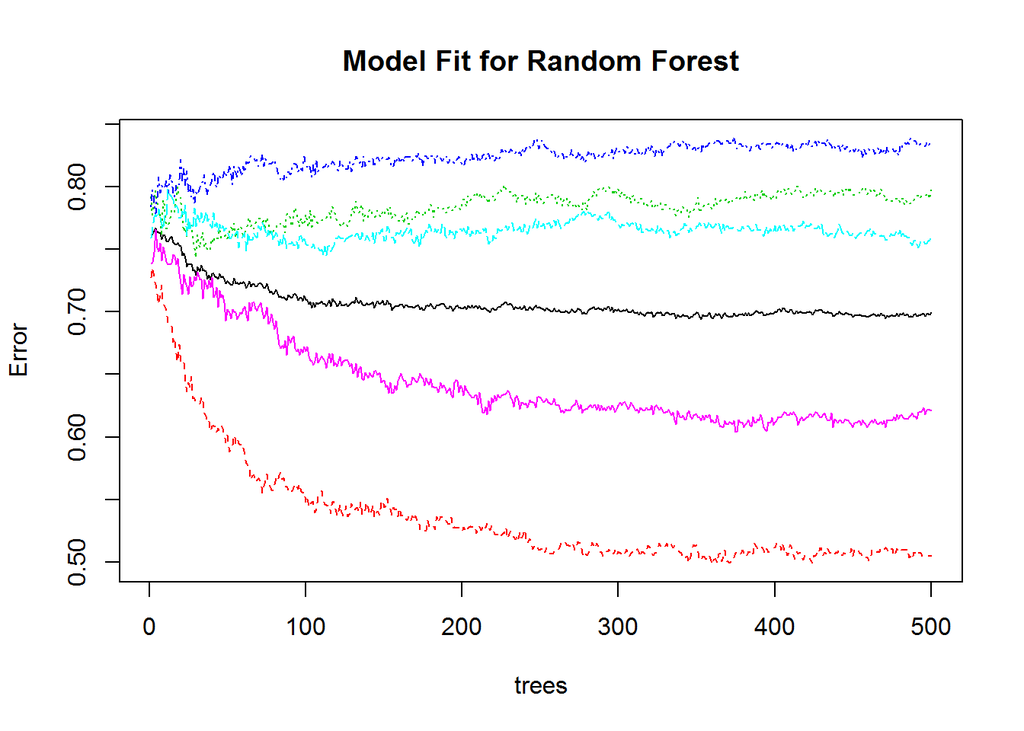

```r
predForest = predict(forest, dataTest, type="class")
plot(forest, main="Model Fit for Random Forest")
```

```r
confusionMatrix(predForest, dataTest$Class)
```

```
## $positive
## NULL
##
## $table
##           Reference
## Prediction   1   2   3   4   5
##          1 220 153  96  67  74
##          2  77  87  68  62  41
##          3  40  53  52  54  36
##          4  41  51  96 108  73
##          5  57  58  72  91 154
##
## $overall
##       Accuracy          Kappa  AccuracyLower  AccuracyUpper   AccuracyNull
##   3.134780e-01   1.392039e-01   2.930857e-01   3.344239e-01   2.195861e-01
## AccuracyPValue  McnemarPValue
##   2.524415e-22   1.205051e-14
##
## $byClass
##          Sensitivity Specificity Pos Pred Value Neg Pred Value Precision
## Class: 1   0.5057471   0.7477361      0.3606557      0.8431802 0.3606557
## Class: 2   0.2164179   0.8429386      0.2597015      0.8086270 0.2597015
## Class: 3   0.1354167   0.8854101      0.2212766      0.8098511 0.2212766
## Class: 4   0.2827225   0.8367730      0.2926829      0.8300248 0.2926829
## Class: 5   0.4074074   0.8265752      0.3564815      0.8553906 0.3564815
##             Recall        F1 Prevalence Detection Rate
## Class: 1 0.5057471 0.4210526  0.2195861     0.11105502
## Class: 2 0.2164179 0.2360923  0.2029278     0.04391721
## Class: 3 0.1354167 0.1680129  0.1938415     0.02624937
## Class: 4 0.2827225 0.2876165  0.1928319     0.05451792
## Class: 5 0.4074074 0.3802469  0.1908127     0.07773852
##          Detection Prevalence Balanced Accuracy
## Class: 1            0.3079253         0.6267416
## Class: 2            0.1691065         0.5296782
## Class: 3            0.1186270         0.5104134
## Class: 4            0.1862696         0.5597477
## Class: 5            0.2180717         0.6169913
##
## $mode
## [1] "sens_spec"
##
## $dots
## list()
##
## attr(,"class")
## [1] "confusionMatrix"
```

```r
tab <- table(true = dataTest$Class, predicted = predForest)
rf5eAcc <- sum(diag(tab)) / sum(tab)
rf5eAcc
```

```
## [1] 0.313478
```

### K-fold cross validation

```r
kfold <- train(Class ~ ., data = subdata, trControl=trainControl(method="cv", number=3), method="rf")
kfpred <- predict(kfold, subdata)

confusionMatrix(kfpred, subdata$Class)
```

```
## Confusion Matrix and Statistics
##
##           Reference
## Prediction    1    2    3    4    5
##          1 1696  187  181  151  106
##          2    0 1369    2    6    4
##          3    0    0 1293    0    1
##          4    2    5    1 1321    5
##          5   24   28   31   27 1378
##
## Overall Statistics
##
##                Accuracy : 0.9027
##                  95% CI : (0.8959, 0.9091)
##     No Information Rate : 0.2203
##     P-Value [Acc > NIR] : < 2.2e-16
##
##                   Kappa : 0.878
##  Mcnemar's Test P-Value : < 2.2e-16
##
## Statistics by Class:
##
##                      Class: 1 Class: 2 Class: 3 Class: 4 Class: 5
## Sensitivity            0.9849   0.8615   0.8574   0.8777   0.9224
## Specificity            0.8975   0.9981   0.9998   0.9979   0.9826
## Pos Pred Value         0.7307   0.9913   0.9992   0.9903   0.9261
## Neg Pred Value         0.9953   0.9658   0.9670   0.9716   0.9817
## Prevalence             0.2203   0.2032   0.1929   0.1925   0.1911
## Detection Rate         0.2169   0.1751   0.1654   0.1690   0.1763
## Detection Prevalence   0.2969   0.1766   0.1655   0.1706   0.1903
## Balanced Accuracy      0.9412   0.9298   0.9286   0.9378   0.9525
```

```r
tab <- table(true = subdata$Class, predicted = kfpred)
kf5eAcc <- sum(diag(tab)) / sum(tab)
kf5eAcc
```

```
## [1] 0.9026605
```

### Bootstrap

```r
bstrap <- train(Class ~ ., data = subdata, trControl=trainControl(method="boot", number=3), method="rf")
bspred <- predict(bstrap, subdata)

confusionMatrix(bspred, subdata$Class)
```

```
## Confusion Matrix and Statistics
##
##           Reference
## Prediction    1    2    3    4    5
##          1 1696  179  179  161  116
##          2    0 1374    2    6    4
##          3    0    0 1294    0    1
##          4    4    7    1 1311    4
##          5   22   29   32   27 1369
##
## Overall Statistics
##
##                Accuracy : 0.901
##                  95% CI : (0.8942, 0.9075)
##     No Information Rate : 0.2203
##     P-Value [Acc > NIR] : < 2.2e-16
##
##                   Kappa : 0.8759
##  Mcnemar's Test P-Value : < 2.2e-16
##
## Statistics by Class:
##
##                      Class: 1 Class: 2 Class: 3 Class: 4 Class: 5
## Sensitivity            0.9849   0.8647   0.8581   0.8711   0.9163
## Specificity            0.8958   0.9981   0.9998   0.9975   0.9826
## Pos Pred Value         0.7276   0.9913   0.9992   0.9879   0.9256
## Neg Pred Value         0.9953   0.9666   0.9672   0.9701   0.9803
## Prevalence             0.2203   0.2032   0.1929   0.1925   0.1911
## Detection Rate         0.2169   0.1757   0.1655   0.1677   0.1751
## Detection Prevalence   0.2982   0.1773   0.1656   0.1697   0.1892
## Balanced Accuracy      0.9404   0.9314   0.9290   0.9343   0.9495
```

```r
tab <- table(true = subdata$Class, predicted = bspred)
bs5eAcc <- sum(diag(tab)) / sum(tab)
bs5eAcc
```

```
## [1] 0.901
```

## Uneven class distribution

### Data Preparation

```r
#Create a copy
data = newsPopularity

#Divide shares into classes
categories = cut(data$shares, c(0, 1000, 2000, 3000, 4000, Inf))
data$Class = as.numeric(categories)
data$Class = factor(data$Class)

set.seed(1313)
indx <- createDataPartition(y = data$Class, p = 0.2)

data <- data[indx$Resample1,]
length(levels(data$Class))
```

```
## [1] 5
```

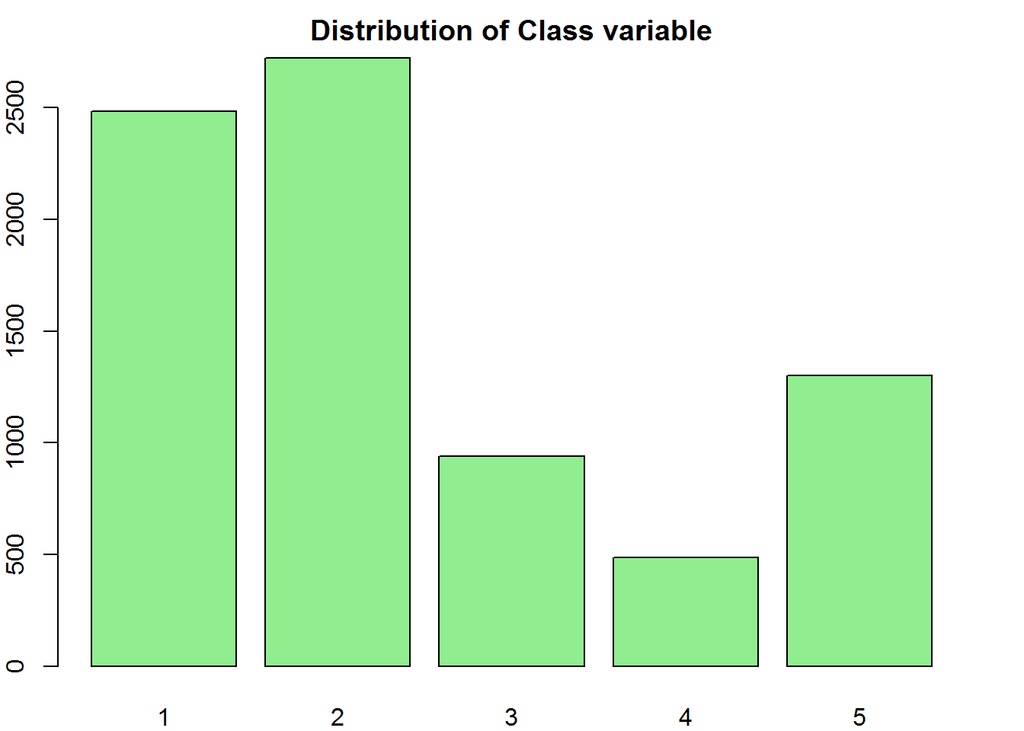

```r
par(mar = rep(2, 4))
barplot(table(data$Class), col="lightgreen", main="Distribution of Class variable")
```

```r
summary(data$Class)
```

```
##    1    2    3    4    5
## 2485 2721  938  486 1300
```

```r
prop.table(table(data$Class))
```

```
##
##          1          2          3          4          5
## 0.31336696 0.34312736 0.11828499 0.06128625 0.16393443
```

```r
data <- subset(data, select = -c(shares))

#Removing near zero variance variables
nzv <- nearZeroVar(data)
names(data)[nzv]
```

```
## [1] "n_non_stop_words" "kw_min_max"
```

```r
data <- data[, -nzv]

#Normalisation
preProcValues <- preProcess(data, method = c("range"))
data <- predict(preProcValues, data)

#Removing highly correlated variables
d.num <- data %>% select(which(sapply(data, is.numeric)))
too_high <- findCorrelation(cor(d.num), cutoff = 0.725, verbose = FALSE)
names(d.num)[too_high]
```

```
##  [1] "n_non_stop_unique_tokens"  "kw_avg_avg"
##  [3] "rate_negative_words"       "data_channel_is_world"
##  [5] "min_negative_polarity"     "LDA_04"
##  [7] "LDA_00"                    "kw_min_min"
##  [9] "self_reference_max_shares" "kw_max_min"
## [11] "self_reference_min_shares"
```

```r
data = data[,-c(too_high)]

#SBF
set.seed(1313)
indx <- createDataPartition(y = data$Class, p = 0.15)
sample <- data[indx$Resample1,]
filterCtrl <- sbfControl(functions = rfSBF, method = "cv", verbose = FALSE)
rfWithFilter <- sbf(form = Class ~ ., data = sample, sbfControl = filterCtrl, allowParallel = TRUE, variables=TRUE)
rfWithFilter
```

```
##
## Selection By Filter
##
## Outer resampling method: Cross-Validated (10 fold)
##
## Resampling performance:
##
##  Accuracy Kappa AccuracySD KappaSD
##    0.4003 0.128    0.04164    0.06
##
## Using the training set, 21 variables were selected:
##    n_tokens_content, n_unique_tokens, num_hrefs, num_imgs, average_token_length...
##
## During resampling, the top 5 selected variables (out of a possible 25):
##    data_channel_is_entertainment (100%), data_channel_is_socmed (100%), data_channel_is_tech (100%), is_weekend (100%), kw_max_avg (100%)
##
## On average, 18.8 variables were selected (min = 15, max = 21)
```

```r
selections <- rfWithFilter$variables$selectedVars
selections
```

```
##  [1] "n_tokens_content"              "n_unique_tokens"
##  [3] "num_hrefs"                     "num_imgs"
##  [5] "data_channel_is_entertainment" "data_channel_is_socmed"
##  [7] "data_channel_is_tech"          "kw_min_avg"
##  [9] "kw_max_avg"                    "self_reference_avg_sharess"
## [11] "weekday_is_tuesday"            "weekday_is_sunday"
## [13] "is_weekend"                    "LDA_02"
## [15] "global_subjectivity"           "global_rate_positive_words"
## [17] "avg_negative_polarity"
```

```r
selections <- append(selections, "Class")

subdata <- data[selections]

#Data splitting
set.seed(1313)
indxTrain <- createDataPartition(y = subdata$Class, p = 0.75)
str(indxTrain)
```

```
## List of 1
##  $ Resample1: int [1:5949] 1 4 6 8 9 10 11 12 14 15 ...
```

```r
dataTrain <- subdata[indxTrain$Resample1,]
dataTest <- subdata[-indxTrain$Resample1,]
```

### Random Forest

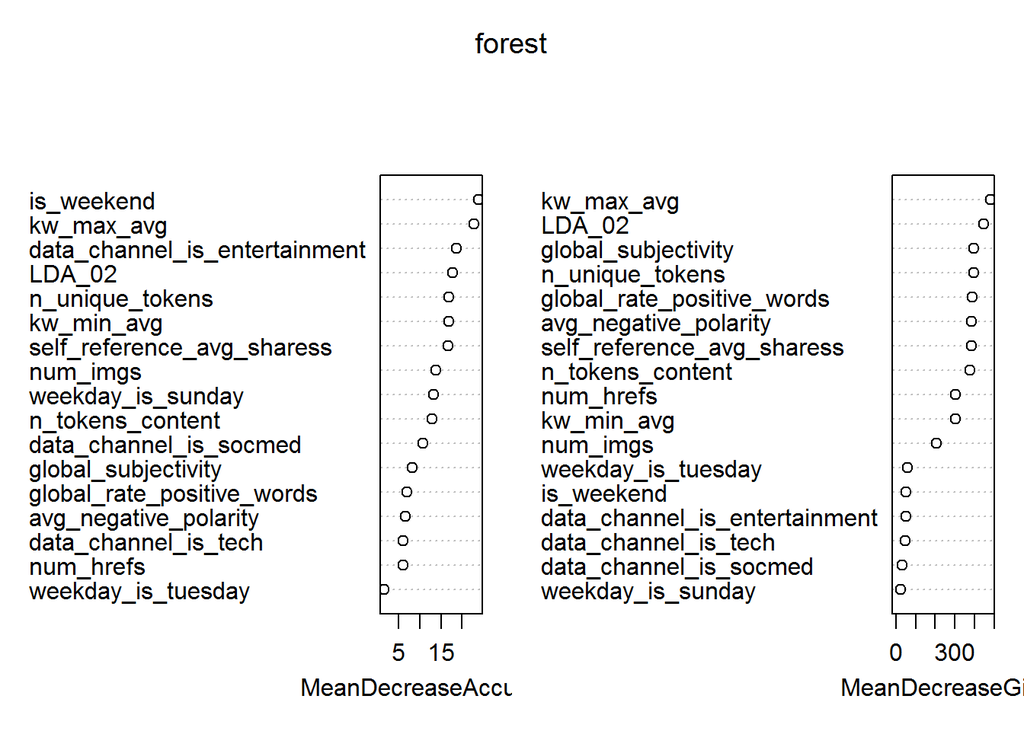

```r
forest <- randomForest(Class ~ ., data = dataTrain, importance = TRUE, na.action = na.omit)
varImpPlot(forest)
```

```r
importance(forest)
```

```
##                                        1           2           3
## n_tokens_content              15.5700325  3.95836652 -2.23628370
## n_unique_tokens               13.9879133 10.58953839 -3.65788510
## num_hrefs                      7.2415891 -0.14361211 -4.29876216
## num_imgs                      17.8050999  2.22452192 -5.42452931
## data_channel_is_entertainment 25.5958646 -1.90851273 -1.00906370
## data_channel_is_socmed        12.5739327 -0.07306696  4.42536555
## data_channel_is_tech          11.3790534 -5.52626973  6.10513419
## kw_min_avg                    24.5001014 -0.38269075 -1.54564360
## kw_max_avg                    19.4492123 -0.31855041 -2.11114232
## self_reference_avg_sharess    20.2241036 -1.28385130  0.25833118
## weekday_is_tuesday             0.7407212  0.93010399  3.04000607
## weekday_is_sunday             15.4378593  5.58913697 -0.60707538
## is_weekend                    35.9682535  4.96894824  2.18997944
## LDA_02                        21.1128645 -2.68746960  0.07847406
## global_subjectivity            5.8890557  6.12263346 -2.51965119
## global_rate_positive_words     5.4542173  1.10555859  0.71686076
## avg_negative_polarity          6.1372077  1.03028226  0.57187042
##                                        4          5 MeanDecreaseAccuracy
## n_tokens_content              -2.8492134  3.0568753            12.866354
## n_unique_tokens               -3.2408276  3.4093036            16.974899
## num_hrefs                     -2.4555209  7.8570303             6.002741
## num_imgs                      -0.2252152  6.8169471            13.894117
## data_channel_is_entertainment  2.9649833  2.6808449            18.627535
## data_channel_is_socmed         3.6599713  5.9358549            10.828756
## data_channel_is_tech          -1.6418070  2.1420476             6.048702
## kw_min_avg                     1.6860502  6.3906367            16.927971
## kw_max_avg                     0.1522937 27.3751319            22.794089
## self_reference_avg_sharess    -0.1454866 11.2243396            16.667998
## weekday_is_tuesday             0.1138771 -0.8408163             1.550218
## weekday_is_sunday             -1.2474003  0.8690752            13.352949
## is_weekend                     2.6319634 -1.5069158            23.952405
## LDA_02                        -0.9921159 14.7335689            17.847424
## global_subjectivity           -2.4656409  3.2865699             8.263853
## global_rate_positive_words     3.2464842  5.1383382             6.927835
## avg_negative_polarity         -3.1379579  7.1503986             6.680963
##                               MeanDecreaseGini
## n_tokens_content                     379.05487
## n_unique_tokens                      395.46619
## num_hrefs                            304.99139
## num_imgs                             204.06536
## data_channel_is_entertainment         48.49235
## data_channel_is_socmed                30.03589
## data_channel_is_tech                  47.24411
## kw_min_avg                           301.77106
## kw_max_avg                           482.72555
## self_reference_avg_sharess           386.00628
## weekday_is_tuesday                    58.60873
## weekday_is_sunday                     25.04289
## is_weekend                            50.76013
## LDA_02                               445.91040
## global_subjectivity                  396.59117
## global_rate_positive_words           390.42254
## avg_negative_polarity                386.03367
```

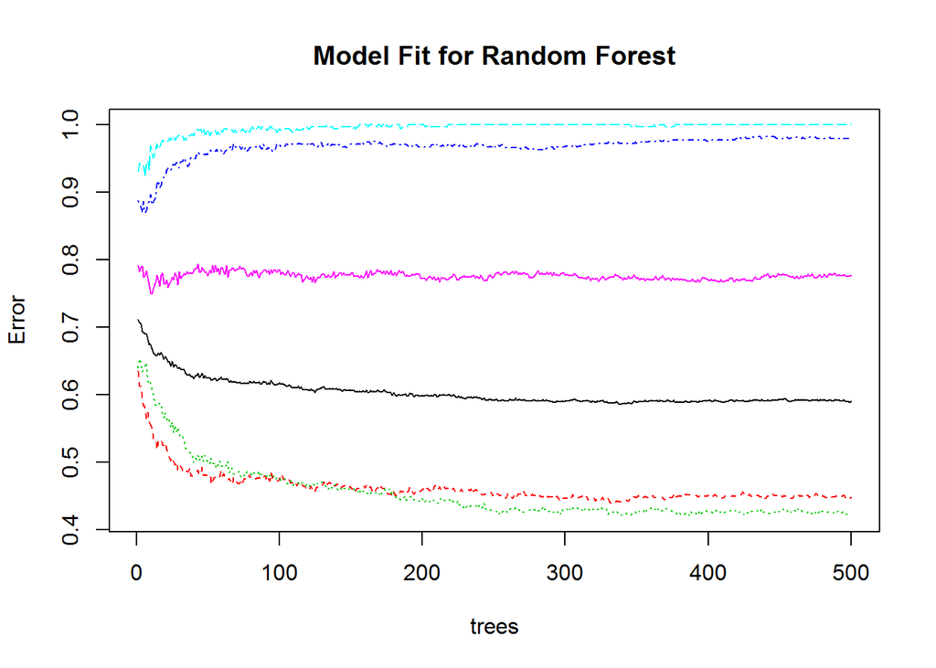

```r
predForest = predict(forest, dataTest, type="class")
plot(forest, main="Model Fit for Random Forest")
```

```r
confusionMatrix(predForest, dataTest$Class)
```

```
## $positive
## NULL
##
## $table
##           Reference
## Prediction   1   2   3   4   5
##          1 362 201  60  23  60
##          2 224 408 138  75 176
##          3   3   5   2   4   3
##          4   0   3   1   0   0
##          5  32  63  33  19  86
##
## $overall
##       Accuracy          Kappa  AccuracyLower  AccuracyUpper   AccuracyNull
##   4.331146e-01   1.795356e-01   4.111549e-01   4.552726e-01   3.432610e-01
## AccuracyPValue  McnemarPValue
##   7.416829e-17   3.645579e-74
##
## $byClass
##          Sensitivity Specificity Pos Pred Value Neg Pred Value Precision
## Class: 1 0.582930757   0.7470588      0.5127479      0.7968627 0.5127479
## Class: 2 0.600000000   0.5288240      0.3996082      0.7166667 0.3996082
## Class: 3 0.008547009   0.9914139      0.1176471      0.8818737 0.1176471
## Class: 4 0.000000000   0.9978495      0.0000000      0.9387962 0.0000000
## Class: 5 0.264615385   0.9112319      0.3690987      0.8632723 0.3690987
##               Recall         F1 Prevalence Detection Rate
## Class: 1 0.582930757 0.54559156 0.31347804    0.182735992
## Class: 2 0.600000000 0.47971781 0.34326098    0.205956588
## Class: 3 0.008547009 0.01593625 0.11812216    0.001009591
## Class: 4 0.000000000        NaN 0.06108026    0.000000000
## Class: 5 0.264615385 0.30824373 0.16405856    0.043412418
##          Detection Prevalence Balanced Accuracy
## Class: 1          0.356385664         0.6649948
## Class: 2          0.515396265         0.5644120
## Class: 3          0.008581524         0.4999804
## Class: 4          0.002019182         0.4989247
## Class: 5          0.117617365         0.5879236
##
## $mode
## [1] "sens_spec"
##
## $dots
## list()
##
## attr(,"class")
## [1] "confusionMatrix"
```

```r
tab <- table(true = dataTest$Class, predicted = predForest)
rf5unAcc <- sum(diag(tab)) / sum(tab)
rf5unAcc
```

```
## [1] 0.4331146
```

### K-fold cross validation

```r
kfold <- train(Class ~ ., data = subdata, trControl=trainControl(method="cv", number=3), method="rf")
kfpred <- predict(kfold, subdata)

confusionMatrix(kfpred, subdata$Class)
```

```
## Confusion Matrix and Statistics
##
##           Reference
## Prediction    1    2    3    4    5
##          1 2384  198  188   93  151
##          2   76 2467  178  120  137
##          3    0    0  552    0    0
##          4    0    0    0  263    0
##          5    0    6    6    4  996
##
## Overall Statistics
##
##                Accuracy : 0.852
##                  95% CI : (0.844, 0.8598)
##     No Information Rate : 0.3416
##     P-Value [Acc > NIR] : < 2.2e-16
##
##                   Kappa : 0.7936
##  Mcnemar's Test P-Value : NA
##
## Statistics by Class:
##
##                      Class: 1 Class: 2 Class: 3 Class: 4 Class: 5
## Sensitivity            0.9691   0.9236   0.5974  0.54792   0.7757
## Specificity            0.8824   0.9007   1.0000  1.00000   0.9976
## Pos Pred Value         0.7910   0.8284   1.0000  1.00000   0.9842
## Neg Pred Value         0.9842   0.9579   0.9488  0.97128   0.9577
## Prevalence             0.3146   0.3416   0.1182  0.06139   0.1642
## Detection Rate         0.3049   0.3155   0.0706  0.03364   0.1274
## Detection Prevalence   0.3855   0.3809   0.0706  0.03364   0.1294
## Balanced Accuracy      0.9258   0.9122   0.7987  0.77396   0.8866
```

```r
tab <- table(true = subdata$Class, predicted = kfpred)
kf5unAcc <- sum(diag(tab)) / sum(tab)
kf5unAcc
```

```
## [1] 0.8520271
```

### Bootstrap

```r
bstrap <- train(Class ~ ., data = subdata, trControl=trainControl(method="boot", number=3), method="rf")
bspred <- predict(bstrap, subdata)

confusionMatrix(bspred, subdata$Class)
```

```
## Confusion Matrix and Statistics
##
##           Reference
## Prediction    1    2    3    4    5
##          1 2402  202  160   93  130
##          2   56 2463  181  119  122
##          3    0    0  575    0    0
##          4    0    0    0  260    0
##          5    2    6    8    8 1032
##
## Overall Statistics
##
##                Accuracy : 0.861
##                  95% CI : (0.8531, 0.8686)
##     No Information Rate : 0.3416
##     P-Value [Acc > NIR] : < 2.2e-16
##
##                   Kappa : 0.8065
##  Mcnemar's Test P-Value : NA
##
## Statistics by Class:
##
##                      Class: 1 Class: 2 Class: 3 Class: 4 Class: 5
## Sensitivity            0.9764   0.9221  0.62229  0.54167   0.8037
## Specificity            0.8908   0.9071  1.00000  1.00000   0.9963
## Pos Pred Value         0.8042   0.8375  1.00000  1.00000   0.9773
## Neg Pred Value         0.9880   0.9574  0.95182  0.97090   0.9627
## Prevalence             0.3146   0.3416  0.11817  0.06139   0.1642
## Detection Rate         0.3072   0.3150  0.07354  0.03325   0.1320
## Detection Prevalence   0.3820   0.3761  0.07354  0.03325   0.1351
## Balanced Accuracy      0.9336   0.9146  0.81115  0.77083   0.9000
```

```r
tab <- table(true = subdata$Class, predicted = bspred)
bs5unAcc <- sum(diag(tab)) / sum(tab)
bs5unAcc
```

```
## [1] 0.8609797
```

# Final Conclusions

```
##                Random Forest    K-fold Bootstrap
## 3-class even       0.4762866 0.9766709 0.9728878
## 3-class uneven     0.5857719 0.9786885 0.9773014
## 5-class even       0.3134780 0.9026605 0.9009977
## 5-class uneven     0.4331146 0.8520271 0.8609797
```

After previous phases we found out the among the methods we learnt Random Forest was the most powerful. In order to get a deeper knowledge in what else could also affect the results we decided to experiment on target variable with 3 and 5 classes, each with even and uneven distribution as well as other sampling methods - `K-fold` cross validation and `Bootstrap`.

In both classifications (3 and 5 class) we observe an increase of 10 percentage points for uneven class in comparison to even class. In our opinion it is like that, because for uneven classes the probabilities are not similar hence chances for correct predictions are higher. However, in both distribution cases, the 5-class yield results much lower, with the difference around `15-16%`. For uneven class distribution the accuracy was `43%` in comparison to `58%` for 3-classes. Nevertheless both results are satisfying when considering the number of classes and comparing to the probability of choosing a correct answer at random.

Moreover, additional sampling methods like `K-fold` and `Bootstrap` gave us much higher results with the highest being `97%` for both sampling methods in case of 3-class classification.

Confusion matrices show that both methods suffered to classify the smallest classes (3 and 4) with around half of them being incorrectly predicted. This is likely due to the fact that `K-fold` and `Bootstrap` use subsets of the data and the smaller classes didn’t occur enough for the forest to be trained properly.

In conclusion, based on results obtained in this phase and the previous ones we can say that the smaller number of classes, the higher accuracy of predictions and it is worth trying different sampling methods as they may give better results than using simple data partition.